# TalkingData

AdTracking Fraud Detection Challenge

Gustavo Moreira

13/07/2019

Este trabalho foi sugerido pela [Data Science Academy](https://www.datascienceacademy.com.br/) durante o curso ‘Formação Cientista de Dados’. Os dados utilizados estão disponíveis na competição [TalkingData AdTracking Fraud Detection Challenge](https://www.kaggle.com/c/talkingdata-adtracking-fraud-detection/overview)

# Introdução

TalkingData é a plataforma de serviços de Big Data mais abrangente da China, cobrindo cerca de 70% dos dispositivos móveis desta nação. Eles recebem dados de aproximadamente 3 bilhões de cliques diários em anúncios de aplicativos(apps). Deste volume, estima-se que 90% dos cliques são potencialmente fraudulentos.

Por fraude, entende-se a realização de cliques em anúncios de apps com a finalidade de elevar o volume de acessos de um canal de comunicação. Dessa forma, o custo financeiro destes canais aumenta, sem representar necessariamente cliques efetuados por usuários reais.

A atual implementação desta empresa para coibir cliques fraudulentos é medir, para cada usuário, a navegação realizada através dos produtos de seu portfólio. A partir dessa métrica, são identificados os IPs que efetuam uma grande quantidade de cliques mas nunca realizaram o download do app anunciado. Registros classificados como fraudulentos são adicionados a uma lista negra de IPs e dispositivos.

A detecção de fraude apresentou ótimos resultados e agora a TalkingData está buscando aprimorar essa implementação: deseja-se prever se um clique realizado resultará no download do app anunciado.

# Definindo o problema de negócio

**Objetivo:** Prever se um clique resultará no download de um app. Cada registro será **classificado** como 0 (não realizou download) e 1 (realizou download)

**Premissas:** Para desenvolver essa solução, será verdadeira a premissa de que os dados disponíveis representam cliques de usuários reais, portanto, não classificados como fraudulentos.

# Observação dos dados disponíveis

```r
input_dir = '../input'

files = list.files(input_dir, '.csv')
sapply(paste(input_dir, files, sep = '/'), file.info)
```

```
##        ../input/sample_submission.csv ../input/test_supplement.csv
## size   195584072                      2665537000
## isdir  FALSE                          FALSE
## mode   420                            420
## mtime  1529492050                     1529492022
## ctime  1562760383                     1562760442
## atime  1562985677                     1529492022
## uid    1000                           1000
## gid    1000                           1000
## uname  "gustavo"                      "gustavo"
## grname "gustavo"                      "gustavo"
##        ../input/test.csv ../input/train_sample.csv ../input/train.csv
## size   863271911         4076438                   7537649302
## isdir  FALSE             FALSE                     FALSE
## mode   420               436                       436
## mtime  1529492044        1518754031                1518753756
## ctime  1562760388        1562760603                1562760603
## atime  1563111264        1563043651                1563062817
## uid    1000              1000                      1000
## gid    1000              1000                      1000
## uname  "gustavo"         "gustavo"                 "gustavo"
## grname "gustavo"         "gustavo"                 "gustavo"
```

Foram disponibilizados os seguintes arquivos:

- train.csv: Dados para treino. Devido ao tamanho deste arquivo, será difícil carregá-lo completamente em memória;
- train_sample.csv: 100.000 amostras extraídas aleatoriamente de train.csv;
- test.csv, test_supplement.csv: Dados para teste;
- sample_submission: Template para avaliar resultado do modelo preditivo.

Serão utilizados os dados de train_sample para análise:

```r
tbl_train_sample = read_csv(paste(input_dir, files[4], sep = '/'))
glimpse(tbl_train_sample)
```

```
## Observations: 100,000
## Variables: 8
## $ ip              <dbl> 87540, 105560, 101424, 94584, 68413, 93663, 1705…
## $ app             <dbl> 12, 25, 12, 13, 12, 3, 1, 9, 2, 3, 3, 3, 3, 6, 2…
## $ device          <dbl> 1, 1, 1, 1, 1, 1, 1, 1, 2, 1, 1, 1, 1, 1, 1, 2, …
## $ os              <dbl> 13, 17, 19, 13, 1, 17, 17, 25, 22, 19, 22, 13, 2…
## $ channel         <dbl> 497, 259, 212, 477, 178, 115, 135, 442, 364, 135…
## $ click_time      <dttm> 2017-11-07 09:30:38, 2017-11-07 13:40:27, 2017-…
## $ attributed_time <dttm> NA, NA, NA, NA, NA, NA, NA, NA, NA, NA, NA, NA,…
## $ is_attributed   <dbl> 0, 0, 0, 0, 0, 0, 0, 0, 0, 0, 0, 0, 0, 0, 0, 0, …
```

- As variáveis ip, app, device, os e channel representam IDs, não devendo ser tratadas como variáveis contínuas;
- A variável is_attributed é o valor a ser previsto, sendo equivalente a 0 ou 1;
- click_time representa a data e hora do clique, enquanto attributed_time representa a data e hora do download.

Antes de prosseguir a análise, vamos verificar quais variáveis estão disponíveis para teste:

```r
tbl_test_sample = read_csv(paste(input_dir, files[3], sep = '/'), n_max = 100)
glimpse(tbl_test_sample)
```

```
## Observations: 100
## Variables: 7
## $ click_id   <dbl> 0, 1, 2, 3, 4, 5, 6, 7, 9, 8, 10, 11, 12, 13, 14, 15,…
## $ ip         <dbl> 5744, 119901, 72287, 78477, 123080, 110769, 12540, 88…
## $ app        <dbl> 9, 9, 21, 15, 12, 18, 3, 27, 18, 12, 26, 3, 12, 9, 12…
## $ device     <dbl> 1, 1, 1, 1, 1, 1, 1, 1, 1, 1, 1, 1, 1, 1, 1, 1, 1, 1,…
## $ os         <dbl> 3, 3, 19, 13, 13, 13, 1, 19, 10, 53, 19, 19, 13, 13, …
## $ channel    <dbl> 107, 466, 128, 111, 328, 107, 137, 153, 107, 424, 477…
## $ click_time <dttm> 2017-11-10 04:00:00, 2017-11-10 04:00:00, 2017-11-10…
```

Todos IDs estão disponíveis para realizar as previsões. Click_ID será associado ao template do arquivo ‘sample_submission’ para avaliar a performance do modelo no Kaggle.

# Análise exploratória

```r
summary(tbl_train_sample)
```

```
##        ip              app             device              os
##  Min.   :     9   Min.   :  1.00   Min.   :   0.00   Min.   :  0.00
##  1st Qu.: 40552   1st Qu.:  3.00   1st Qu.:   1.00   1st Qu.: 13.00
##  Median : 79827   Median : 12.00   Median :   1.00   Median : 18.00
##  Mean   : 91256   Mean   : 12.05   Mean   :  21.77   Mean   : 22.82
##  3rd Qu.:118252   3rd Qu.: 15.00   3rd Qu.:   1.00   3rd Qu.: 19.00
##  Max.   :364757   Max.   :551.00   Max.   :3867.00   Max.   :866.00
##
##     channel        click_time
##  Min.   :  3.0   Min.   :2017-11-06 16:00:00
##  1st Qu.:145.0   1st Qu.:2017-11-07 11:34:09
##  Median :258.0   Median :2017-11-08 07:07:50
##  Mean   :268.8   Mean   :2017-11-08 06:29:52
##  3rd Qu.:379.0   3rd Qu.:2017-11-09 02:06:01
##  Max.   :498.0   Max.   :2017-11-09 15:59:51
##
##  attributed_time               is_attributed
##  Min.   :2017-11-06 17:19:04   Min.   :0.00000
##  1st Qu.:2017-11-07 11:50:27   1st Qu.:0.00000
##  Median :2017-11-08 06:43:39   Median :0.00000
##  Mean   :2017-11-08 07:04:12   Mean   :0.00227
##  3rd Qu.:2017-11-09 01:42:52   3rd Qu.:0.00000
##  Max.   :2017-11-09 15:28:15   Max.   :1.00000
##  NA's   :99773
```

```r
table(tbl_train_sample$is_attributed)
```

```
##
##     0     1
## 99773   227
```

Os registros dessa análise foram coletados entre os dias 06/11/2017 e 09/11/2017. Dos 100.000 cliques observados, apenas 227 downloads foram efetuados. Isso sugere que a grande maioria dos cliques costumam não resultar em um download.

Para detectar as diferenças entre registros que resultam em um download, será necessário balancear a quantidade de registros de cada classe, de forma a obter uma distribuição equilibrada:

```r
set.seed(1)
tbl_undersample <- bind_rows(tbl_train_sample %>% filter(is_attributed == 1),
                             tbl_train_sample %>% filter(is_attributed == 0) %>% sample_n(227))
glimpse(tbl_undersample)
```

```
## Observations: 454
## Variables: 8
## $ ip              <dbl> 224120, 272894, 79001, 131029, 40352, 48733, 330…
## $ app             <dbl> 19, 10, 19, 19, 19, 35, 35, 5, 71, 35, 19, 5, 19…
## $ device          <dbl> 0, 1, 0, 0, 0, 1, 1, 1, 1, 1, 16, 1, 21, 1, 1, 1…
## $ os              <dbl> 29, 7, 0, 0, 0, 18, 22, 32, 25, 19, 0, 31, 24, 1…
## $ channel         <dbl> 213, 113, 213, 343, 213, 274, 21, 113, 3, 21, 21…
## $ click_time      <dttm> 2017-11-08 02:22:13, 2017-11-08 06:10:05, 2017-…
## $ attributed_time <dttm> 2017-11-08 02:22:38, 2017-11-08 06:10:37, 2017-…
## $ is_attributed   <dbl> 1, 1, 1, 1, 1, 1, 1, 1, 1, 1, 1, 1, 1, 1, 1, 1, …
```

## Feature Engineering

Apenas as variáveis disponíveis neste dataset não são suficientes para esclarecer se um clique resultará em um download. Com os dados disponíveis, pensei em calcular as seguintes métricas:

- Média de downloads por app, device, os e channel;
- Média de cliques por app, device, os e channel;
- Extrair componentes da data e hora do clique: dia da semana, dia, hora, minuto, segundo.

```r
## Granularizar o campo click_date
strip_date = function(tib){
  tbl_date <- tib %>%
    transmute(click_day = day(click_time),
              click_dayofweek = as.POSIXlt(click_time)$wday,
              click_hour = hour(click_time),
              click_minute = minute(click_time),
              click_second = second(click_time))
  return(bind_cols(tib, tbl_date) %>% select(-click_time))
}

#Média de downloads por app
mean_app_downloads = function(tbl){
  return(tbl %>%
           group_by(app) %>%
           summarize(mean_app_downloads = mean(is_attributed)) %>%
           ungroup)
}

#Média de downloads por dispositivo
mean_device_downloads = function(tbl){
  return(tbl %>%
           group_by(device) %>%
           summarize(mean_device_downloads = mean(is_attributed)) %>%
           ungroup)
}

#Média de downloads por sistema operacional
mean_os_downloads = function(tbl){
  return(tbl %>%
           group_by(os) %>%
           summarize(mean_os_downloads = mean(is_attributed)) %>%
           ungroup)
}

#Média de downloads por canal
mean_channel_downloads = function(tbl){
  return(tbl %>%
           group_by(channel) %>%
           summarize(mean_channel_downloads = mean(is_attributed)) %>%
           ungroup)
}

#Média de cliques por aplicativo
mean_app_clicks = function(tbl){
  total_clicks = nrow(tbl)
  tbl_clicks = tbl %>% count(app)
  return(tbl_clicks %>%
           mutate(n = n / total_clicks) %>%
           rename(mean_app_clicks = n))
}

#Média de cliques por dispositivo
mean_device_clicks = function(tbl){
  total_clicks = nrow(tbl)
  tbl_clicks = tbl %>% count(device)
  return(tbl_clicks %>%
           mutate(n = n / total_clicks) %>%
           rename(mean_device_clicks = n))
}

#Média de cliques por sistema operacional
mean_os_clicks = function(tbl){
  total_clicks = nrow(tbl)
  tbl_clicks = tbl %>% count(os)
  return(tbl_clicks %>%
           mutate(n = n / total_clicks) %>%
           rename(mean_os_clicks = n))
}

#Média de cliques por canal
mean_channel_clicks = function(tbl){
  total_clicks = nrow(tbl)
  tbl_clicks = tbl %>% count(channel)
  return(tbl_clicks %>%
           mutate(n = n / total_clicks) %>%
           rename(mean_channel_clicks = n))
}
```

```r
#Elaborando features com base em downloads
tbl_dl_app <- mean_app_downloads(tbl_undersample)
tbl_dl_device <- mean_device_downloads(tbl_undersample)
tbl_dl_os <- mean_os_downloads(tbl_undersample)
tbl_dl_channel <- mean_channel_downloads(tbl_undersample)

#Elaborando features com base em cliques
tbl_click_app <- mean_app_clicks(tbl_undersample)
tbl_click_device <- mean_device_clicks(tbl_undersample)
tbl_click_os <- mean_os_clicks(tbl_undersample)
tbl_click_channel <- mean_channel_clicks(tbl_undersample)
```

```r
tbl_undersample <- tbl_undersample %>%
  strip_date() %>%
  left_join(tbl_dl_app, by = 'app') %>%
  left_join(tbl_dl_device, by = 'device') %>%
  left_join(tbl_dl_os, by = 'os') %>%
  left_join(tbl_dl_channel, by = 'channel') %>%
  left_join(tbl_click_app, by = 'app') %>%
  left_join(tbl_click_device, by = 'device') %>%
  left_join(tbl_click_os, by = 'os') %>%
  left_join(tbl_click_channel, by = 'channel')
```

## Correlação entre features

Após calcular e associar cada média a seu ID e extrair os componentes de data e hora, verificamos a correlação entre as variáveis elaboradas:

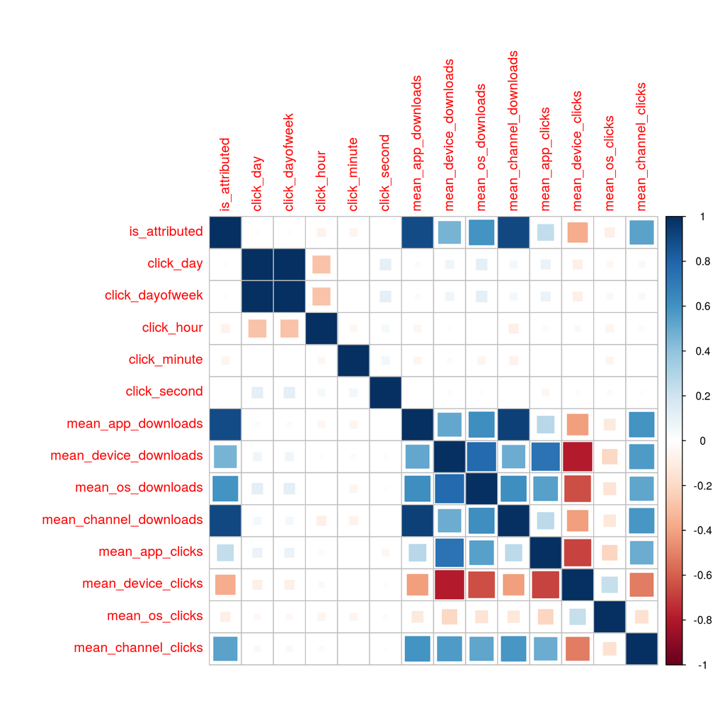

```r
tbl_undersample_corr <- tbl_undersample %>%
  select(-ip, -app, -device, -os, -channel) %>%
  select_if(is.numeric) %>%
  cor()
corrplot(tbl_undersample_corr, method = ('square'))
```

Dessa matriz de correlação, podemos extrair as seguintes informações:

- O momento do clique possui pouca influência sobre a decisão do usuário realizar o download do app;
- As variáveis ‘app’ e ‘channel’ exercem uma influência maior na decisão do usuário realizar o download do app, ao passo que as variáveis ‘device’ e ‘os’ exercem uma influência menor;
- Há uma forte correlação negativa da variável device com as demais.

## Visualizações

Para buscar compreender melhor cada variável, será necessário elaborar algumas visualizações mais específicas.

### Downloads por app

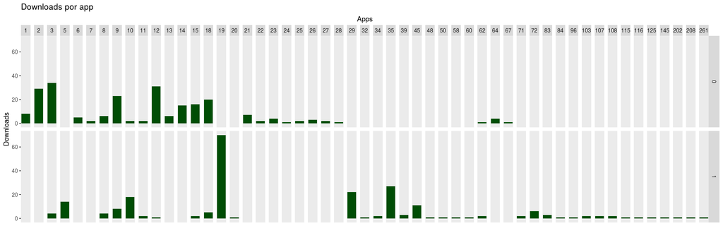

```r
ggplot(data = tbl_undersample) +
  geom_histogram(mapping = aes(x = app),
                 bins = 1,
                 fill = '#004d05') +
  scale_x_continuous(position = 'top') +
  theme(panel.grid = element_blank(),
        axis.text.x = element_blank(),
        axis.ticks.x = element_blank()) +
  xlab('Apps') + ylab('Downloads') +
  ggtitle('Downloads por app') +
  facet_grid(is_attributed ~ app)
```

### Downloads por device

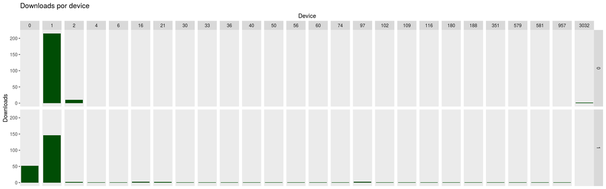

```r
ggplot(data = tbl_undersample) +
  geom_histogram(mapping = aes(x = device),
                 bins = 1,
                 fill = '#004d05') +
  scale_x_continuous(position = 'top') +
  theme(panel.grid = element_blank(),
        axis.text.x = element_blank(),
        axis.ticks.x = element_blank()) +
  xlab('Device') + ylab('Downloads') +
  ggtitle('Downloads por device') +
  facet_grid(is_attributed ~ device)
```

### Downloads por os

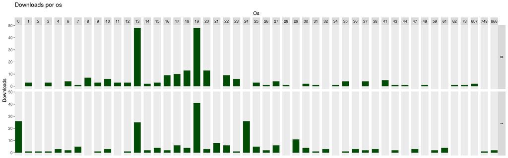

```r
ggplot(data = tbl_undersample) +
  geom_histogram(mapping = aes(x = os),
                 bins = 1,
                 fill = '#004d05') +
  scale_x_continuous(position = 'top') +
  theme(panel.grid = element_blank(),
        axis.text.x = element_blank(),
        axis.ticks.x = element_blank()) +
  xlab('Os') + ylab('Downloads') +
  ggtitle('Downloads por os') +
  facet_grid(is_attributed ~ os)
```

### Downloads por channel

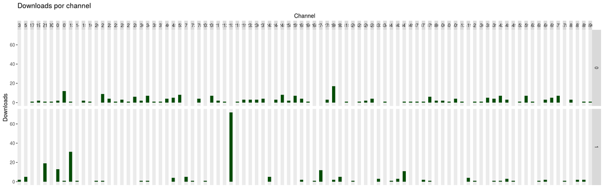

```r
ggplot(data = tbl_undersample) +
  geom_histogram(mapping = aes(x = channel),
                 bins = 1,
                 fill = '#004d05') +
  scale_x_continuous(position = 'top') +
  theme(panel.grid = element_blank(),
        axis.text.x = element_blank(),
        axis.ticks.x = element_blank()) +
  xlab('Channel') + ylab('Downloads') +
  ggtitle('Downloads por channel') +
  facet_grid(is_attributed ~ channel)
```

### Downloads por hora do dia

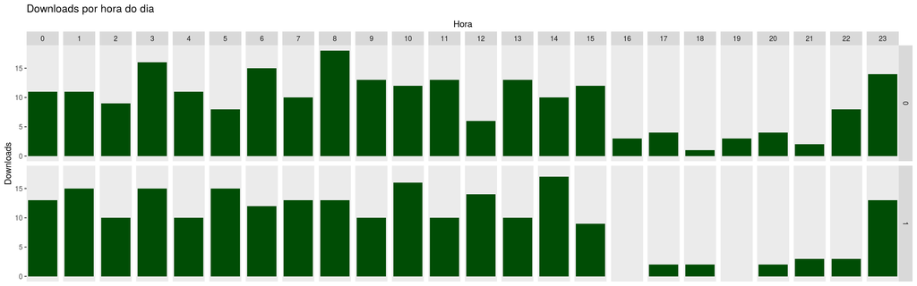

```r
ggplot(data = tbl_undersample) +
  geom_histogram(mapping = aes(x = click_hour),
                 bins = 1,
                 fill = '#004d05') +
  scale_x_continuous(position = 'top') +
  theme(panel.grid = element_blank(),
        axis.text.x = element_blank(),
        axis.ticks.x = element_blank()) +
  xlab('Hora') + ylab('Downloads') +
  ggtitle('Downloads por hora do dia') +
  facet_grid(is_attributed ~ click_hour)
```

- Alguns apps e channels obtém mais sucesso que os demais ao induzir um usuário a clicar e efetuar download. Percebemos isso observando a variação entre os IDs;
- Apesar da variedade de dispositivos, a grande maioria dos cliques originaram do device 1. Há pouca variação entre downloads realizados por clique, sugerindo que o dispositivo do usuário não influencia em sua decisão de efetuar o download. O device 0 possui participação significativa entre os dispositivos que efetuaram download, entretanto, não obtivemos amostras no grupo oposto para verificar a variabilidade deste registro;
- Semelhante aos dispositivos, o sistema operacional do usuário possui pouca variação quando comparado às classes previstas, sugerindo que não há influência dessa variável ao determinar a realização de um download;
- O horário do clique também possui pouca variação, sugerindo que essa variável não influencia na decisão do usuário em realizar download do app.

# Concepção do modelo preditivo

Mesmo com as observações apontadas durante a análise, optei por utilizar todas as variáveis para conceber o modelo preditivo. Durante a criação, utilizei algumas técnicas para escolher quais variáveis seriam mantidas ou descartadas.

## Carregando dados para treino

Precisamos carregar mais dados para treinar o modelo preditivo, entretanto, é inviável carregar todo este dataset em memória na minha estação de trabalho:

```r
system('wc -l ../input/train.csv')
```

Existem aproximadamente 185 milhões de registros disponíveis para treino. Optei por extrair 9 partições de 2.000.000 registros para cada 10% deste documento:

```r
#Índices de leitura do arquivo de treino
start_row_index <- 184903891 * seq(0.1, 0.9, 0.1)

#Função para agrupar uma coleção de tibbles
merge_inputs_by_row = function(..., is_attributed = NA){
  if(is.na(is_attributed)){
    return(bind_rows(...))
  }
  return(bind_rows(...) %>% filter(is_attributed == !!is_attributed))
}

#Extraindo partições a partir de cada índice
data_list <- lapply(start_row_index, function(x){
  read_csv(paste(input_dir, files[5], sep = '/'),
           n_max = 2000000, skip = x, col_names = c('ip', 'app', 'device', 'os',
                                                    'channel', 'click_time', 'attributed_time',
                                                    'is_attributed'))
})

#Agrupando os dados
tbl_train <- merge_inputs_by_row(data_list)

#Excluindo a lista, para disponibilizar mais espaço em memória
rm('data_list')
```

```r
table(tbl_train$is_attributed)
```

```
##
##        0        1
## 17952169    47831
```

Semelhante ao processo realizado durante análise, o modelo preditivo será treinado com um dataset balanceado:

```r
set.seed(5)
train_sample <- tbl_train %>%
  filter(is_attributed == 1)

train_sample <- bind_rows(train_sample,
                          tbl_train %>%
                            filter(is_attributed == 0) %>%
                            sample_n(nrow(train_sample)))
```

## Cálculo de features

Com o dataset devidamente balanceado, calculamos as features de downloads, cliques e data e hora:

```r
train_sample <- train_sample %>%
  select(-ip, -attributed_time) %>%
  strip_date()

#Features baseadas em downloads
tbl_dl_app <- mean_app_downloads(train_sample)
tbl_dl_device <- mean_device_downloads(train_sample)
tbl_dl_os <- mean_os_downloads(train_sample)
tbl_dl_channel <- mean_channel_downloads(train_sample)

#Features baseadas em cliques
tbl_click_app <- mean_app_clicks(train_sample)
tbl_click_device <- mean_device_clicks(train_sample)
tbl_click_os <- mean_os_clicks(train_sample)
tbl_click_channel <- mean_channel_clicks(train_sample)

#Realizado os cálculos, colocamos a variável target como fator
train_sample <- train_sample %>%
  mutate(is_attributed = as.factor(is_attributed))

#Agrupando os dados extraídos
train_sample <- train_sample %>%
  left_join(tbl_dl_app, by = 'app') %>%
  left_join(tbl_dl_device, by = 'device') %>%
  left_join(tbl_dl_os, by = 'os') %>%
  left_join(tbl_dl_channel, by = 'channel') %>%
  left_join(tbl_click_app, by = 'app') %>%
  left_join(tbl_click_device, by = 'device') %>%
  left_join(tbl_click_os, by = 'os') %>%
  left_join(tbl_click_channel, by = 'channel') %>%
  select(-app, -device, -os, -channel)
```

## Criação do modelo

Escolhi resolver este problema utilizando um algoritmo de regressão logística:

```r
t_index = createDataPartition(train_sample$is_attributed, times = 1, p = 0.7, list = F)
train = train_sample[t_index,]
test = train_sample[-t_index,]
```

```r
global_formula = formula(is_attributed ~ .)
glm_model = glm(global_formula, data = train, family = 'binomial')
step_model = step(glm_model, direction = 'both')
```

```
## Start:  AIC=30077.63
## is_attributed ~ click_day + click_dayofweek + click_hour + click_minute +
##     click_second + mean_app_downloads + mean_device_downloads +
##     mean_os_downloads + mean_channel_downloads + mean_app_clicks +
##     mean_device_clicks + mean_os_clicks + mean_channel_clicks
##
##
## Step:  AIC=30077.63
## is_attributed ~ click_day + click_hour + click_minute + click_second +
##     mean_app_downloads + mean_device_downloads + mean_os_downloads +
##     mean_channel_downloads + mean_app_clicks + mean_device_clicks +
##     mean_os_clicks + mean_channel_clicks
##
##                          Df Deviance   AIC
## - click_minute            1    30052 30076
## - click_second            1    30052 30076
## <none>                         30052 30078
## - click_day               1    30055 30079
## - mean_channel_clicks     1    30055 30079
## - click_hour              1    30070 30094
## - mean_device_downloads   1    30074 30098
## - mean_app_clicks         1    30079 30103
## - mean_os_downloads       1    30188 30212
## - mean_os_clicks          1    30266 30290
## - mean_device_clicks      1    30412 30436
## - mean_channel_downloads  1    31150 31174
## - mean_app_downloads      1    33300 33324
##
## Step:  AIC=30075.79
## is_attributed ~ click_day + click_hour + click_second + mean_app_downloads +
##     mean_device_downloads + mean_os_downloads + mean_channel_downloads +
##     mean_app_clicks + mean_device_clicks + mean_os_clicks + mean_channel_clicks
##
##                          Df Deviance   AIC
## - click_second            1    30052 30074
## <none>                         30052 30076
## - click_day               1    30055 30077
## + click_minute            1    30052 30078
## - mean_channel_clicks     1    30056 30078
## - click_hour              1    30070 30092
```

[output cut: 12 more lines]

```
##
##                          Df Deviance   AIC
## <none>                         30052 30074
## - click_day               1    30055 30075
## + click_second            1    30052 30076
## - mean_channel_clicks     1    30056 30076
## + click_minute            1    30052 30076
## - click_hour              1    30070 30090
## - mean_device_downloads   1    30074 30094
## - mean_app_clicks         1    30079 30099
## - mean_os_downloads       1    30189 30209
## - mean_os_clicks          1    30267 30287
## - mean_device_clicks      1    30413 30433
## - mean_channel_downloads  1    31151 31171
## - mean_app_downloads      1    33301 33321
```

```r
summary(step_model)
```

```
##
## Call:
## glm(formula = is_attributed ~ click_day + click_hour + mean_app_downloads +
##     mean_device_downloads + mean_os_downloads + mean_channel_downloads +
##     mean_app_clicks + mean_device_clicks + mean_os_clicks + mean_channel_clicks,
##     family = "binomial", data = train)
##
## Deviance Residuals:
##     Min       1Q   Median       3Q      Max
## -3.0729  -0.4026   0.0182   0.1694   3.2716
##
## Coefficients:
##                         Estimate Std. Error z value Pr(>|z|)
## (Intercept)            -6.183941   0.235916 -26.212  < 2e-16 ***
## click_day              -0.036190   0.020490  -1.766   0.0774 .
## click_hour             -0.010383   0.002445  -4.246 2.17e-05 ***
## mean_app_downloads      4.787553   0.086925  55.077  < 2e-16 ***
## mean_device_downloads   0.957486   0.206312   4.641 3.47e-06 ***
## mean_os_downloads       1.805245   0.153596  11.753  < 2e-16 ***
## mean_channel_downloads  2.740309   0.080923  33.863  < 2e-16 ***
## mean_app_clicks         2.517495   0.483418   5.208 1.91e-07 ***
## mean_device_clicks      2.277763   0.135005  16.872  < 2e-16 ***
## mean_os_clicks          2.634909   0.181511  14.517  < 2e-16 ***
## mean_channel_clicks     1.361848   0.698976   1.948   0.0514 .
## ---
## Signif. codes:  0 '***' 0.001 '**' 0.01 '*' 0.05 '.' 0.1 ' ' 1
##
## (Dispersion parameter for binomial family taken to be 1)
##
##     Null deviance: 92832  on 66963  degrees of freedom
## Residual deviance: 30052  on 66953  degrees of freedom
## AIC: 30074
##
## Number of Fisher Scoring iterations: 7
```

A melhor fórmula calculada pela função step sugere a utilização de todas as médias calculadas em conjunto com o dia e hora do clique. A média de cliques por canal e o dia do clique apresentaram um baixo grau de significância, sugerindo pouca influência no modelo preditivo.

## Validação do modelo

```r
step_formula = formula(is_attributed ~ click_hour + mean_app_downloads +
                         mean_device_downloads + mean_os_downloads + mean_channel_downloads +
                         mean_app_clicks + mean_device_clicks + mean_os_clicks)
tr_c = trainControl(method = 'repeatedcv', number = 10, repeats = 10)
step_model = train(step_formula, data = train, method = 'glm', family = 'binomial', trControl = tr_c)
```

Com o modelo treinado, podemos avaliar a importância de cada variável:

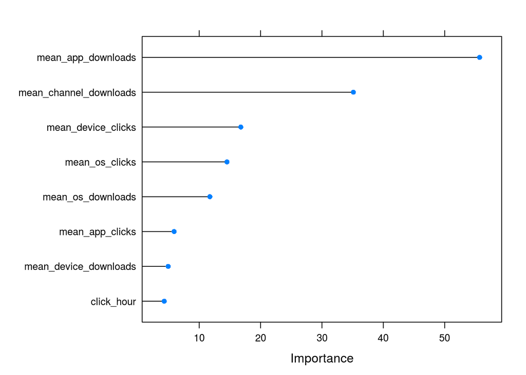

```r
plot(varImp(step_model, scale=F))
```

Este gráfico demonstra mais precisamente o grau de importância de cada variável. Futuramente, podemos criar novas versões do modelo preditivo utilizando combinações diferentes dessas variáveis.

Concluído o treinamento do modelo, faremos as previsões sobre os dados de teste deste conjunto:

```r
step_preds = predict.train(step_model, test)
confusionMatrix(step_preds, test$is_attributed, positive = '1')
```

```
## Confusion Matrix and Statistics
##
##           Reference
## Prediction     0     1
##          0 13908  1920
##          1   441 12429
##
##                Accuracy : 0.9177
##                  95% CI : (0.9145, 0.9209)
##     No Information Rate : 0.5
##     P-Value [Acc > NIR] : < 2.2e-16
##
##                   Kappa : 0.8355
##
##  Mcnemar's Test P-Value : < 2.2e-16
##
##             Sensitivity : 0.8662
##             Specificity : 0.9693
##          Pos Pred Value : 0.9657
##          Neg Pred Value : 0.8787
##              Prevalence : 0.5000
##          Detection Rate : 0.4331
##    Detection Prevalence : 0.4485
##       Balanced Accuracy : 0.9177
##
##        'Positive' Class : 1
##
```

Este modelou apresentou 91% de acurácia (capacidade de classificar corretamente o valor previsto) e 86% de sensibilidade (capacidade de classificar corretamente a ocorrência de downloads).

Entretanto, estes valores foram obtidos a partir de um dataset balanceado. Sabemos que é esperado um volume muito menor de downloads por clique e precisamos testar este modelo com novos dados.

## Teste do modelo

Serão extraídos aleatoriamente registros do dataset original. Essa abordagem possui alguns problemas:

- Apesar da aleatoriedade, é possível que sejam selecionados registros já observados durante o treinamento;
- É provável que sejam selecionados IDs não observados durante o treinamento, portanto, o cálculo da média de registros não observados anteriormente será NA.

Para solucionar o primeiro problema, optei por extrair um conjunto de dados pelo menos 10 vezes maior que o conjunto utilizado para treino. Dessa forma, mesmo que todos registros observados durante o treinamento sejam aleatoriamente selecionados, ainda existirá um grande volume de dados não observados.

Para o segundo problema, optei por imputar um valor constante igual a 0 visto que não conhecemos a média de cliques ou downloads dos IDs não observados:

```r
set.seed(11)
tbl_unbalanced_test = tbl_train %>% sample_n(1000000)

#Atribuindo features baseadas no dataset de treino
tbl_unbalanced_test <- tbl_unbalanced_test %>%
  select(-ip, -attributed_time) %>%
  mutate(is_attributed = as.factor(is_attributed)) %>%
  strip_date() %>%
  left_join(tbl_dl_app, by = 'app') %>%
  left_join(tbl_dl_device, by = 'device') %>%
  left_join(tbl_dl_os, by = 'os') %>%
  left_join(tbl_dl_channel, by = 'channel') %>%
  left_join(tbl_click_app, by = 'app') %>%
  left_join(tbl_click_device, by = 'device') %>%
  left_join(tbl_click_os, by = 'os') %>%
  left_join(tbl_click_channel, by = 'channel') %>%
  select(-app, -device, -os, -channel) %>%
  replace(is.na(.), 0)
```

Com novos dados preparados, testamos o modelo novamente:

```r
unbalanced_preds = predict.train(step_model, tbl_unbalanced_test)
confusionMatrix(unbalanced_preds, tbl_unbalanced_test$is_attributed, positive = '1')
```

```
## Confusion Matrix and Statistics
##
##           Reference
## Prediction      0      1
##          0 965503    354
##          1  31773   2370
##
##                Accuracy : 0.9679
##                  95% CI : (0.9675, 0.9682)
##     No Information Rate : 0.9973
##     P-Value [Acc > NIR] : 1
##
##                   Kappa : 0.1242
##
##  Mcnemar's Test P-Value : <2e-16
##
##             Sensitivity : 0.870044
##             Specificity : 0.968140
##          Pos Pred Value : 0.069414
##          Neg Pred Value : 0.999633
##              Prevalence : 0.002724
##          Detection Rate : 0.002370
##    Detection Prevalence : 0.034143
##       Balanced Accuracy : 0.919092
##
##        'Positive' Class : 1
##
```

O modelo obteve 96% de acurácia ao ser testado com dados inéditos, sugerindo que não ocorreu *overfitting* durante o treinamento e sua capacidade de generalização foi preservada.

Entretanto, o modelo previu a ocorrência de 34143 downloads, quando na realidade houveram apenas 2724. Isso sugere que o modelo está bastante sensível a classificar incorretamente a ocorrência de downloads.